# Problem Sets

## **Problem Set 4: ANOVA**

### **Question 1**

#### You are hired by the US Department of Agriculture to develop effective control practices for invasive plants (data_ANOVA.xlsx). In particular, you are asked to investigate pesticide controls for kudzu which is an invasive vine that grows in thick mats that smother underlying plants. Two of the most widely used pesticides for kudzu are glyphosate and triclopyr. To determine the effectiveness of a single application of pesticide, you conduct an experiment in 18 plots that each had 50% kudzu cover. In mid-summer, you applied equal amounts of 2% glyphosate to 6 plots, 2% triclopyr to 6 plots, and water without pesticides to 6 plots. Then you returned in autumn and measured the percent cover of kudzu in the plots.

```r
# Load libraries
library(readxl)    # read xlsx format
library(reshape2)  # to use the melt function
```

```r
library(ggplot2)   # for data viz
```

#### a) Transform the data from wide to long format

```r
# Read in  wide format data
data_wide <- read_xlsx("C:\\Users\\hlear\\Desktop\\statsandviz\\R04_anova\\data\\data_ANOVA.xlsx")

# Explore data
head(data_wide)
```

```
## # A tibble: 6 × 3
##   Glyphosate Triclopyr Control
##        <dbl>     <dbl>   <dbl>
## 1         20        17      34
## 2         17        14      31
## 3         24        12      29
## 4         18        16      32
## 5         16        18      27
## 6         22        13      30
```

```r
colnames(data_wide)
```

```
## [1] "Glyphosate" "Triclopyr"  "Control"
```

```r
class(data_wide)
```

```
## [1] "tbl_df"     "tbl"        "data.frame"
```

```r
# Melt the data into long format
data_long <- melt(data_wide, id.vars = NULL)

# Explore data
data_long
```

```
##      variable value
## 1  Glyphosate    20
## 2  Glyphosate    17
## 3  Glyphosate    24
## 4  Glyphosate    18
## 5  Glyphosate    16
## 6  Glyphosate    22
## 7   Triclopyr    17
## 8   Triclopyr    14
## 9   Triclopyr    12
## 10  Triclopyr    16
## 11  Triclopyr    18
## 12  Triclopyr    13
## 13    Control    34
## 14    Control    31
## 15    Control    29
## 16    Control    32
## 17    Control    27
## 18    Control    30
```

```r
colnames(data_long)
```

```
## [1] "variable" "value"
```

```r
class(data_long)
```

```
## [1] "data.frame"
```

#### b) Make a boxplot of the data

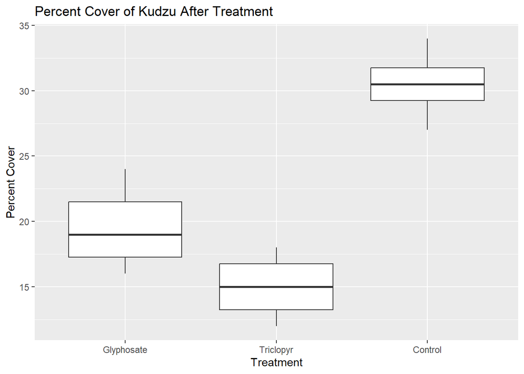

```r
# boxplot using ggplot2

ggplot(data_long, aes(x = variable, y = value)) +
  geom_boxplot() +
  ggtitle("Percent Cover of Kudzu After Treatment") +
  xlab("Treatment") +
  ylab("Percent Cover")
```

#### c) Perform an ANOVA

In this output, the p-value is very small (1.318e-07), which suggests that there is a significant difference between the means of the groups. The “***” sign next to the p-value indicates that the results are highly significant (p < 0.001).

```r
# Fit a linear regression model
model <- lm(value ~ variable, data = data_long)

# Perform an ANOVA on the model
anova(model)
```

```
## Analysis of Variance Table
##
## Response: value
##           Df Sum Sq Mean Sq F value    Pr(>F)
## variable   2    763   381.5    54.5 1.318e-07 ***
## Residuals 15    105     7.0
## ---
## Signif. codes:  0 '***' 0.001 '**' 0.01 '*' 0.05 '.' 0.1 ' ' 1
```

#### d) What is the variation explained (R2)?

The resulting R-squared value indicates that the regression model fits the data well.

```r
summary(model)$r.squared
```

```
## [1] 0.8790323
```

#### e) Perform a post hoc test

```r
# Perform Tukey's test
TukeyHSD(aov(value~variable, data=data_long))
```

```
##   Tukey multiple comparisons of means
##     95% family-wise confidence level
##
## Fit: aov(formula = value ~ variable, data = data_long)
##
## $variable
##                      diff       lwr        upr     p adj
## Triclopyr-Glyphosate -4.5 -8.467701 -0.5322987 0.0255594
## Control-Glyphosate   11.0  7.032299 14.9677013 0.0000087
## Control-Triclopyr    15.5 11.532299 19.4677013 0.0000001
```

### **Question 2**

#### Data in growth.txt come from a farm-scale trial of animal diets. There are two factors: diet and supplement. Diet is a factor with three levels: barley, oats and wheat. Supplement is a factor with four levels: agrimore, control, supergain and supersupp. The response variable is weight gain after 6 weeks.

```r
# Read in data
data <- read.table("C:\\Users\\hlear\\Desktop\\statsandviz\\R04_anova\\data\\growth.txt", sep = "\t", header = TRUE)

# Explore data
class(data)
```

```
## [1] "data.frame"
```

```r
head(data)
```

```
##   supplement  diet     gain
## 1  supergain wheat 17.37125
## 2  supergain wheat 16.81489
## 3  supergain wheat 18.08184
## 4  supergain wheat 15.78175
## 5    control wheat 17.70656
## 6    control wheat 18.22717
```

```r
colnames(data)
```

```
## [1] "supplement" "diet"       "gain"
```

#### a) Inspect the data using boxplots

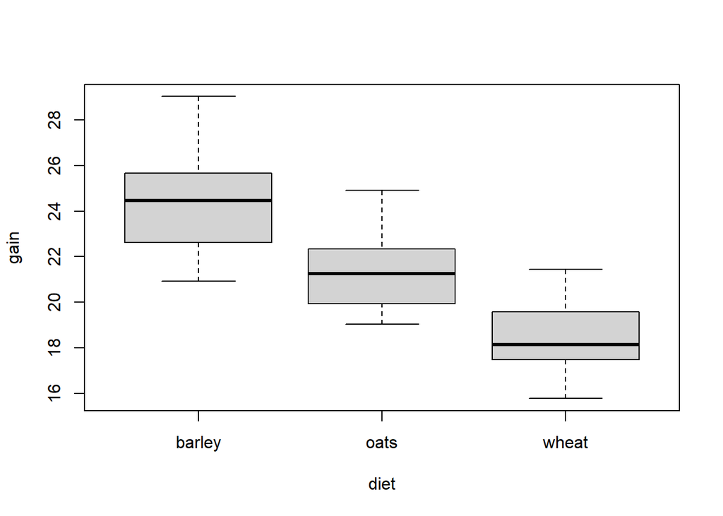

```r
# Create Boxplot
boxplot(gain~diet, data=data)             # weight gain as a function of diet
```

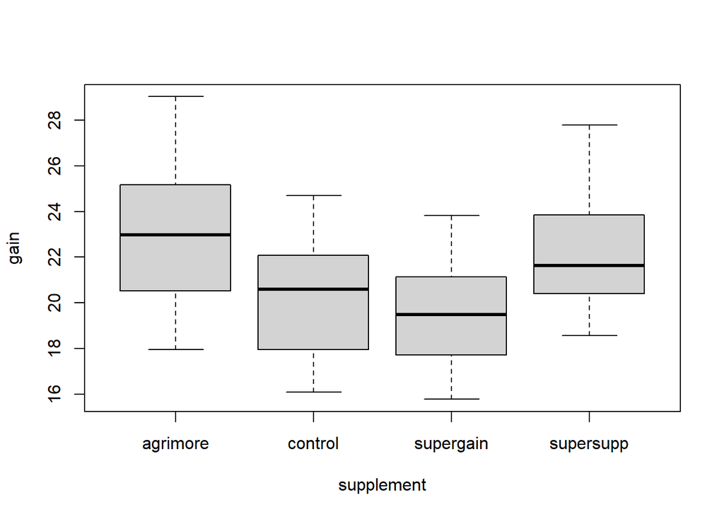

```r
boxplot(gain~supplement, data=data)       # weight gain as a function of supplement
```

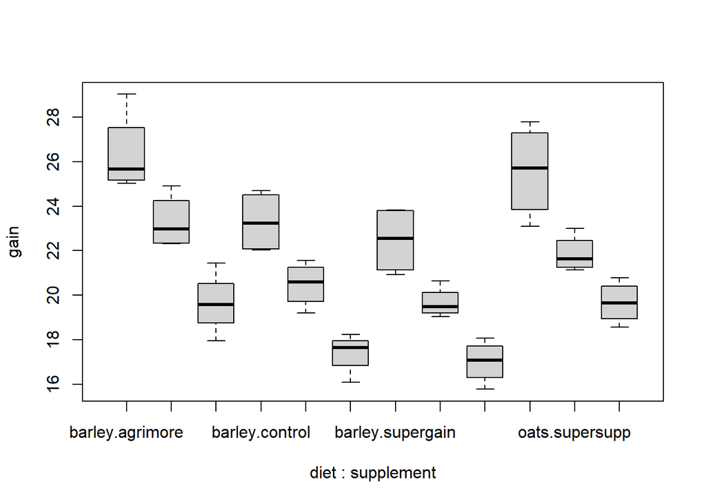

```r
boxplot(gain~diet+supplement, data=data)  # weight gain for each combination of diet/supplement
```

#### b) Perform a two-way ANOVA

```r
anova(lm(gain~diet+supplement, data=data))   # without interaction
```

```
## Analysis of Variance Table
##
## Response: gain
##            Df  Sum Sq Mean Sq F value    Pr(>F)
## diet        2 287.171 143.586  92.358 4.199e-16 ***
## supplement  3  91.881  30.627  19.700 3.980e-08 ***
## Residuals  42  65.296   1.555
## ---
## Signif. codes:  0 '***' 0.001 '**' 0.01 '*' 0.05 '.' 0.1 ' ' 1
```

```r
summary(lm(gain~diet+supplement, data=data))$r.squared # for R-squared
```

```
## [1] 0.8530521
```

```r
anova(lm(gain~diet*supplement, data=data))   # includes interaction
```

```
## Analysis of Variance Table
##
## Response: gain
##                 Df  Sum Sq Mean Sq F value    Pr(>F)
## diet             2 287.171 143.586 83.5201 2.999e-14 ***
## supplement       3  91.881  30.627 17.8150 2.952e-07 ***
## diet:supplement  6   3.406   0.568  0.3302    0.9166
## Residuals       36  61.890   1.719
## ---
## Signif. codes:  0 '***' 0.001 '**' 0.01 '*' 0.05 '.' 0.1 ' ' 1
```

```r
summary(lm(gain~diet*supplement, data=data))$r.squared # for R-squared
```

```
## [1] 0.8607168
```

#### (Exploration: Aikaike Information Criterion)

```r
# install.packages("AICcmodavg")
# library(AICcmodavg)

# Fit the first linear regression model
two_way <- lm(gain ~ diet + supplement, data = data)

# Extract the AIC value for the first model
aic_two_way <- AIC(two_way)

# Fit the second linear regression model
interaction <- lm(gain ~ diet * supplement, data = data)

# Extract the AIC value for the second model
aic_interaction <- AIC(interaction)

# Compare the AIC values to determine which model is best
if (aic_two_way < aic_interaction) {
  cat("The two_way model is better, with AIC =", aic_two_way)
} else {
  cat("The interaction model is better, with AIC =", aic_interaction)
}
```

```
## The two_way model is better, with AIC = 164.9892
```

#### c) Assess graphically if there exists an interaction between both factors

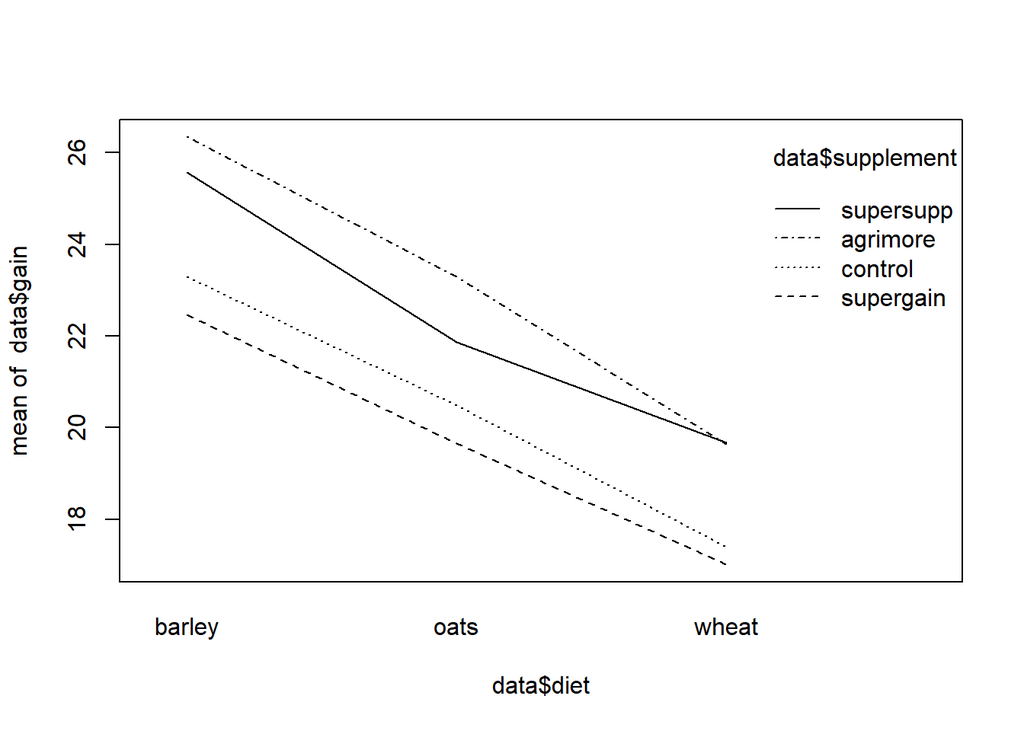

```r
interaction.plot(data$diet, data$supplement, data$gain)  # supersupp and agrimore intersect at wheat
```

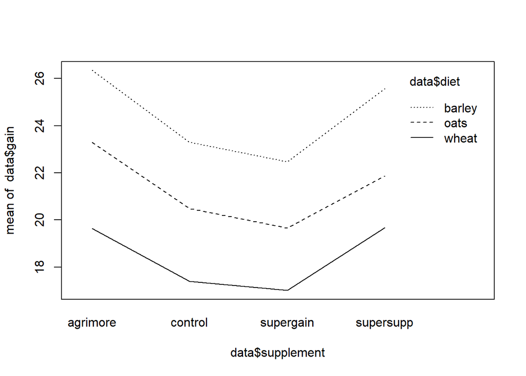

```r
interaction.plot(data$supplement, data$diet, data$gain)  # parallel (little to no interaction)
```

#### d) Given what you learnt about the interaction, what would be a better model?

The two-way (no interaction) model is better.

#### e) What is the variation explained (R2) of this new model?

```r
anova(lm(gain~diet+supplement, data=data))    # without interaction
```

```
## Analysis of Variance Table
##
## Response: gain
##            Df  Sum Sq Mean Sq F value    Pr(>F)
## diet        2 287.171 143.586  92.358 4.199e-16 ***
## supplement  3  91.881  30.627  19.700 3.980e-08 ***
## Residuals  42  65.296   1.555
## ---
## Signif. codes:  0 '***' 0.001 '**' 0.01 '*' 0.05 '.' 0.1 ' ' 1
```

```r
summary(lm(gain~diet+supplement, data=data))$r.squared  # for R-squared
```

```
## [1] 0.8530521
```

#### f) Perform a Tukey HSD test of this new model

```r
TukeyHSD(aov(gain~diet+supplement, data=data))
```

```
##   Tukey multiple comparisons of means
##     95% family-wise confidence level
##
## Fit: aov(formula = gain ~ diet + supplement, data = data)
##
## $diet
##                   diff       lwr       upr p adj
## oats-barley  -3.092817 -4.163817 -2.021817 0e+00
## wheat-barley -5.990298 -7.061298 -4.919297 0e+00
## wheat-oats   -2.897481 -3.968481 -1.826481 2e-07
##
## $supplement
##                           diff        lwr        upr     p adj
## control-agrimore    -2.6967005 -4.0583332 -1.3350677 0.0000234
## supergain-agrimore  -3.3814586 -4.7430914 -2.0198259 0.0000003
## supersupp-agrimore  -0.7273521 -2.0889849  0.6342806 0.4888738
## supergain-control   -0.6847581 -2.0463909  0.6768746 0.5400389
## supersupp-control    1.9693484  0.6077156  3.3309811 0.0020484
## supersupp-supergain  2.6541065  1.2924737  4.0157392 0.0000307
```

## **Problem Set 5: Correlation**

**Packages**

```r
library(corrgram)  # graphical display of a correlation matrix (correlogram)
library(cowplot)   # creae publication-quality figures with ggplot2
```

### **Question 1**

#### In a study of hyena laughter, a researcher investigated whether sound spectral properties of hyenas’ giggles are associated with age.

#### Age(years): 2,2,2,6,9,10,13,10,14,14,12,7,11,11,14,20

#### Frequency (Hz): 840,670,580,470,540,660,510,520,500,480,400,650,460,500,580,500

#### a) Inspect the data using a scatterplot

#### b) Test the linear association between both variables

#### c) Assume that the data are not normally distributed, test the linear association using a non-parametric correlation coefficient

#### a) Inspect the data using a scatterplot

```r
# Put the data into a data frame for manipulation
hyena <- data.frame(age = c(2,2,2,6,9,10,13,10,14,14,12,7,11,11,14,20),
                    Hz = c(840,670,580,470,540,660,510,520,500,480,400,650,460,500,580,500))

# Explore data
class(hyena)
```

```
## [1] "data.frame"
```

```r
head(hyena)
```

```
##   age  Hz
## 1   2 840
## 2   2 670
## 3   2 580
## 4   6 470
## 5   9 540
## 6  10 660
```

```r
colnames(hyena)
```

```
## [1] "age" "Hz"
```

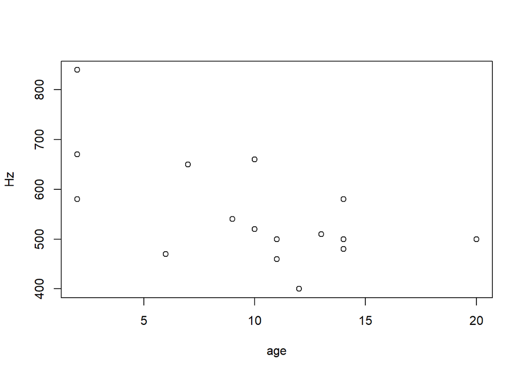

```r
# Quick inspection of the data
# Plot using base R
plot(hyena)
```

#### b) Test the linear association between both variables

```r
# Hypothesis test on the correlation coefficient
cor.test(hyena$age, hyena$Hz, method = "pearson")
```

```
##
##  Pearson's product-moment correlation
##
## data:  hyena$age and hyena$Hz
## t = -2.8194, df = 14, p-value = 0.01365
## alternative hypothesis: true correlation is not equal to 0
## 95 percent confidence interval:
##  -0.8453293 -0.1511968
## sample estimates:
##       cor
## -0.601798
```

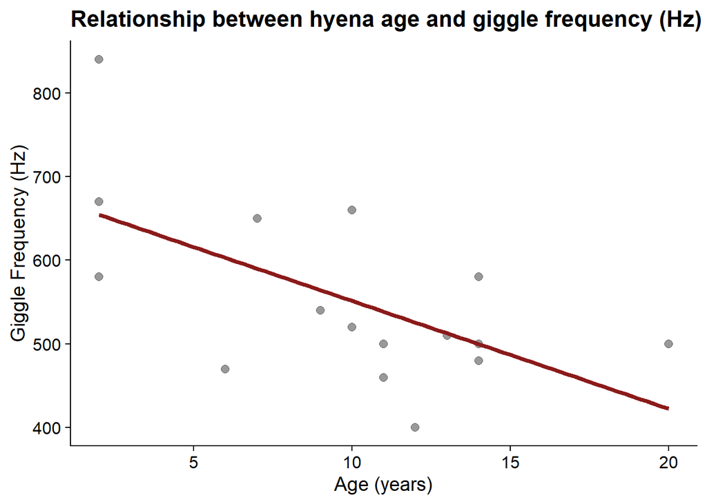

```r
# Plot using ggplot2
ggplot(data=hyena, aes(x=age, y=Hz)) +
  geom_point(size=2.5, alpha=0.4) +
  geom_smooth(method="lm", se=F, size=1.5, color="firebrick4") +
  xlab("Age (years)") +
  ylab("Giggle Frequency (Hz)") +
  ggtitle("Relationship between hyena age and giggle frequency (Hz)") +
  theme_cowplot(14)
```

#### c) Test the linear association using a non-parametric correlation coefficient

```r
# Non-parametric rank correlation methods (Spearman, Kendall)
cor(hyena, method="spearman")
```

```
##            age         Hz
## age  1.0000000 -0.5397807
## Hz  -0.5397807  1.0000000
```

```r
cor(hyena, method="kendall")
```

```
##            age         Hz
## age  1.0000000 -0.4211174
## Hz  -0.4211174  1.0000000
```

## **Problem Set 6: Regression**

### **Question 1**

#### Testosterone is known to predict aggressive behavior and is involved in face shape during puberty. Does face shape predict aggression?

#### Researchers measured the face width-to-height ratio of 21 university hockey players with the average number of penalty minutes awarded per game for aggressive infractions.Data are available in face.txt.

#### a) How steeply does the number of penalty minutes increase per unit increase in face ratio? Calculate the estimate of the intercept. Write the result in the form of an equation for the line.